# Practical Machine Learning Project

Dmitry Malugin [GitHub](https://github.com/PainKKKiller/practicalMachineLearning.git)

## Introduction of the Data Set

This document describe the analysis done for the prediction assignment of the practical machine learning course. We are required to assess how well barbell are performed by subjects equiped with accelerometers on the belt, arm, forearm, and dumbells.

## Download and prepare data

Load pakages. For our machine learning we’ll be use randomForest, it has shown best results in my attempts

```r
library(caret)
library(randomForest)
```

The first step is to load the csv file data to dataframe and analyze the type & the completion rate of the data (commands are commented to limit the output size. You can run it deleting the “#” ) :

```r
data <- read.csv("data/pml-training.csv")
#summary(data)
#describe(data)
#sapply(data, class)
#str(data)
```

Then, data set has been split into 2 parts:

- training (70%)
- testing (30%)

```r
detail <- data[data$new_window == "no",]
set.seed(1981)
inTrain<- createDataPartition(y=detail$classe, p=.7,list=F)
Training <-detail[inTrain,]
Testing<-detail[-inTrain,]
```

And has been done some preprocessing.

```r
# eliminate the features that are completed NA
predictors <- sapply(1:160, function(x) all(!is.na(Training[,x]) & is.numeric(Training[,x])))
# exclude the first columns not suited as predictors
predictors[1:7] <- FALSE
num.predictors <- sum(predictors)
TrainingNoNA <- Training[ ,predictors]
# center and scale features
prepro <- preProcess(TrainingNoNA, method=c("center", "scale"))
TrainingCenSca <- predict(prepro, TrainingNoNA)
# add the outcome variable
TrainingCenSca[ ,"classe"] <- Training[ ,"classe"]
```

52 predictors are kept. TrainingNoNA contains only these features.

## The First Iteration of the Random Forest Classifier

```r
# Use randomForest package to predict the classes
modelFitRf <- randomForest(classe ~ ., data = TrainingCenSca, importance=TRUE)
modelFitRf
```

```
##
## Call:
##  randomForest(formula = classe ~ ., data = TrainingCenSca, importance = TRUE)
##                Type of random forest: classification
##                      Number of trees: 500
## No. of variables tried at each split: 7
##
##         OOB estimate of  error rate: 0.65%
## Confusion matrix:
##      A    B    C    D    E class.error
## A 3823    4    0    1    2 0.001827676
## B   15 2583    5    0    0 0.007683442
## C    0   19 2325    3    0 0.009373669
## D    0    0   29 2172    2 0.014071720
## E    0    0    2    5 2463 0.002834008
```

## Elimination of the Least Significant Features

The importance of the features can be assessed using the varImp function.

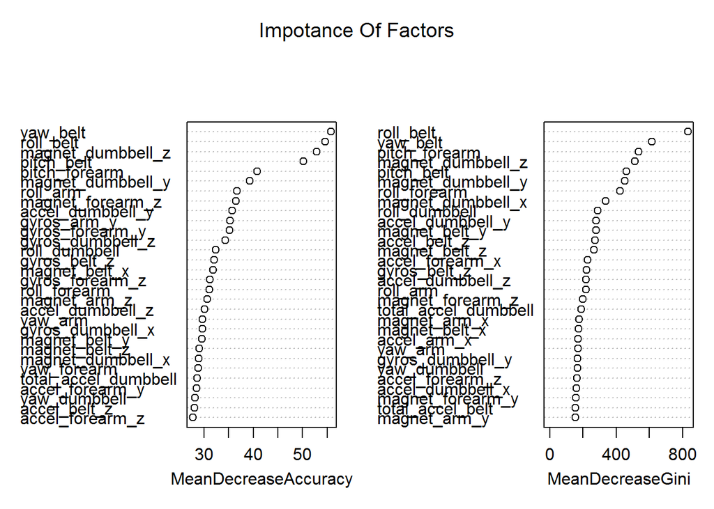

```r
varImpPlot(modelFitRf, sort=TRUE, main="Impotance Of Factors");
```

```r
vi <- (varImp(modelFitRf))
# Let us illustrate the selection with the median.
i <- 50
threshold <- apply(vi, 2, function(x) quantile(x, probs = i / 100))
keep.var <- apply(vi, 1, function(x) any(x > threshold))
predictors2 <- rownames(vi)[!is.na(keep.var) & keep.var == TRUE]
TrainingSel <- TrainingCenSca[,predictors2]
# add the outcome variable
TrainingSel[,"classe"] <- Training[,"classe"]
modelFitRfSel <- randomForest(classe ~ ., data = TrainingSel, importance=TRUE)
modelFitRfSel
```

```
##
## Call:
##  randomForest(formula = classe ~ ., data = TrainingSel, importance = TRUE)
##                Type of random forest: classification
##                      Number of trees: 500
## No. of variables tried at each split: 6
##
##         OOB estimate of  error rate: 0.65%
## Confusion matrix:
##      A    B    C    D    E class.error
## A 3824    5    0    0    1 0.001566580
## B   16 2579    8    0    0 0.009220131
## C    0   13 2326    8    0 0.008947593
## D    0    0   27 2174    2 0.013163867
## E    0    0    2    6 2462 0.003238866
```

The main advantage of this simplification is that it depends on less features:

```r
predictors2
```

```
##  [1] "roll_belt"            "pitch_belt"           "yaw_belt"
##  [4] "gyros_belt_z"         "accel_belt_z"         "magnet_belt_x"
##  [7] "magnet_belt_y"        "magnet_belt_z"        "roll_arm"
## [10] "pitch_arm"            "yaw_arm"              "gyros_arm_y"
## [13] "accel_arm_z"          "magnet_arm_y"         "magnet_arm_z"
## [16] "roll_dumbbell"        "yaw_dumbbell"         "total_accel_dumbbell"
## [19] "gyros_dumbbell_x"     "gyros_dumbbell_y"     "gyros_dumbbell_z"
## [22] "accel_dumbbell_y"     "accel_dumbbell_z"     "magnet_dumbbell_x"
## [25] "magnet_dumbbell_y"    "magnet_dumbbell_z"    "roll_forearm"
## [28] "pitch_forearm"        "yaw_forearm"          "total_accel_forearm"
## [31] "gyros_forearm_y"      "accel_forearm_x"      "accel_forearm_y"
## [34] "accel_forearm_z"      "magnet_forearm_y"     "magnet_forearm_z"
```

If we would vary `i` from 50 to 100, we would not find any better quantile threshold than the median on this data set using the seed 1208 before each run of Random Forest. Due to space limitations we do not include this computation in the assignment. When we reduce the number of predictors, the loss of accuracy is very mild, as long as we keep at least 10 to 20 variables as shown by the `rfcv` function results below.

The function `rfcv` computes the out of sample error rate by using cross validation when less and less variables are used.

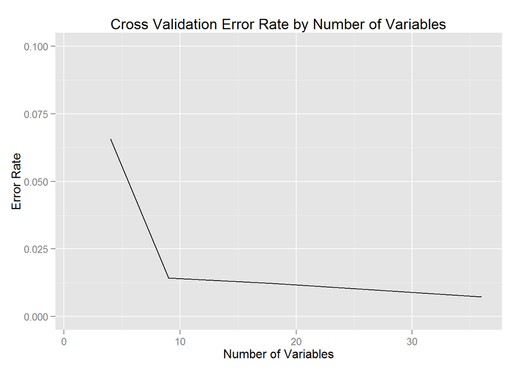

```r
library(ggplot2)
set.seed(1981)
res <- rfcv(TrainingSel[,-dim(TrainingSel)[2]], TrainingSel[,"classe"], cv.fold = 10)
qplot(res$n.var, res$error.cv, xlab="Number of Variables", ylab="Error Rate", main="Cross Validation Error Rate by Number of Variables", geom="line", ylim = c(0,0.1))
```

Since in the other part of the assignment, the prediction accuracy is the sole criterion that matters, we keep our 36-variable model: it does not overfit and provides the least error rate.

As noticed on the discussion forum, “random forests” has its own mechanism of cross validation built in: the out of bag error explained above and K-fold cross validation should not be needed.

```r
library(cvTools)
set.seed(1208)
K <- 10
R <- 1
errorRates <- rep(NA,K)
folds <- cvFolds(dim(TrainingSel)[1], K = K, R = R)
for (i in 1:K) {
  TestingIndex <- folds$subsets[folds$which == i]
  model <- randomForest(classe ~ ., data=TrainingSel[-TestingIndex,])
  res <- predict(model,TrainingSel[TestingIndex,])
  errorRates[i] <- sum(res != TrainingSel[TestingIndex,"classe"]) / length(res)
}
```

## The Final Test

Now our model is ready, and we use it to predict the classes of the test set.

```r
TestingNoNA <- Testing[,predictors]
TestingCenSca <- predict(prepro,TestingNoNA)
TestingCenSca[,"classe"] <- Testing[,"classe"]
# check the handcrafted model
ClassesPredicted <- predict(modelFitRfSel, TestingCenSca)
confusionMatrix(ClassesPredicted, TestingCenSca[,"classe"])
```

```
## Confusion Matrix and Statistics
##
##           Reference
## Prediction    A    B    C    D    E
##          A 1641    6    0    0    0
##          B    0 1109    4    0    0
##          C    0    0 1000    5    1
##          D    0    0    1  939    2
##          E    0    0    0    0 1055
##
## Overall Statistics
##
##                Accuracy : 0.9967
##                  95% CI : (0.9949, 0.998)
##     No Information Rate : 0.2847
##     P-Value [Acc > NIR] : < 2.2e-16
##
##                   Kappa : 0.9958
##  Mcnemar's Test P-Value : NA
##
## Statistics by Class:
##
##                      Class: A Class: B Class: C Class: D Class: E
## Sensitivity            1.0000   0.9946   0.9950   0.9947   0.9972
## Specificity            0.9985   0.9991   0.9987   0.9994   1.0000
## Pos Pred Value         0.9964   0.9964   0.9940   0.9968   1.0000
## Neg Pred Value         1.0000   0.9987   0.9989   0.9990   0.9994
## Prevalence             0.2847   0.1935   0.1744   0.1638   0.1836
## Detection Rate         0.2847   0.1924   0.1735   0.1629   0.1831
## Detection Prevalence   0.2858   0.1931   0.1746   0.1635   0.1831
## Balanced Accuracy      0.9993   0.9969   0.9969   0.9970   0.9986
```

On this data set the out-of-bag estimate of the error rate is really reliable.